# 3220103172

Zhehao Chen

2024-07-08

## 1.

#### (a) (5,8,1,5,8,1,…,5,8,1) where there are 10 occurrences of 5.

To create a vector that repeats the sequence (5, 8, 1) so that there are 10 occurrences of 5, you can use the rep function:

```r
tmp <- c(5, 8, 1)
vec_a <- rep(tmp, times = 10)
print(vec_a)
```

```
##  [1] 5 8 1 5 8 1 5 8 1 5 8 1 5 8 1 5 8 1 5 8 1 5 8 1 5 8 1 5 8 1
```

#### (b) (5,5,…,5,8,8,…,8,1,1,…,1) where there are 30 occurrences of 5, 20 occurrences of 8 and 10 occurrences of 1.

To create a vector with 30 occurrences of 5, 20 occurrences of 8, and 10 occurrences of 1, you can use the rep function with the times argument as a vector:

```r
tmp <- c(5, 8, 1)
times <- c(30, 20, 10)
vec_b <- rep(tmp, times = times)
print(vec_b)
```

```
##  [1] 5 5 5 5 5 5 5 5 5 5 5 5 5 5 5 5 5 5 5 5 5 5 5 5 5 5 5 5 5 5 8 8 8 8 8 8 8 8
## [39] 8 8 8 8 8 8 8 8 8 8 8 8 1 1 1 1 1 1 1 1 1 1
```

## 2.

Execute the following lines which create two vectors of random integers which are chosen with replacement from the integers 0,1,…,999. Both vectors have length 250.

```r
 xVec <- sample(0:999, 250, replace=T)
 yVec <- sample(0:999, 250, replace=T)
 xVec
```

```
##   [1] 641  74 589 833 392 237 941 715 307 355 730  47 996 198 456 544 407 281
##  [19] 765  90 410 179 232 546 760 873 169 775 449 533 168  74 670 845 631  12
##  [37] 308 714 444 271 876 143 550 519 315  57 554 542 411 415 189 969   4 530
##  [55]  95 161 796 159 221 793 524 698 553 378 253 312 303 704 139 329  41  81
##  [73]  72 512 499 809 689 582 504 801 132 398 949 957 441 802 543 617 487 734
##  [91] 318 547 915 189 649 465  61 148  12 961 870 281 136 539 780 979  86 993
## [109] 959 454 420  42  51   0 445 704 845 738 306  79  62 708 411 346 577 114
## [127] 961 971 491 598 158 961 945 997 782 563 437 629 576 654 245 167 352 169
## [145]  56 940 622  68  98 989 725 264 312 348 263  11  32 800 944 608 576 441
## [163]  95 230 266 852 399 136 625 175 566 247 739 500 909  51  14  41 326 888
## [181] 324 225 539 891 642 298 853 696 654 433 310  32 252 943 699 911 878 913
## [199] 489 671 246 223 426 608 179 225 153 799 444 227 341 129 453 958  84 246
## [217] 252  97 592  12 754 778 504 904 103 303 450 108 400 700 313 802 990 616
## [235]  32 977  35  32 669 145 143 180 533 590 260 893 470 182 570 814
```

```r
 yVec
```

```
##   [1] 683 563 340 371 468 343 501 164 527 820 174 943 186 350 506 711 573 997
##  [19] 889 428 850 672 457 509 527 298 461 238  97 127 183 920 823  77 824 831
##  [37] 879 600 445 231 268 235 972  39 501 396 839 512  38 664 533 990 941 466
##  [55] 390 300 311 419 612 107 320 549 300 879 848 956 817 235 862 836 164 356
##  [73] 192 450 472 305  51 850 759 933 724 398 586 343 924 665 946 951 346 570
##  [91]  56 922  20 942 832 428 843 805 191 730 968 528 454 260 846 278 202 774
## [109] 267 882 248 314 918 738 529 419 710 267 425 703 354 108 240 466  36 266
## [127] 828 403 338 798 354  98 988  85 446 195 603 377 851  89  26 868 803 526
## [145] 364 636 851 961 648 883  37 848 212 283 163 274  98 635 962  96 438   2
## [163] 370 371 677 126  38 375  41  26 373 264 698 664 862 112 580 999 527 640
## [181] 603 212 292 181 892 898 901 861 966 883 320 478 736 556 527 843 414 349
## [199] 401 128 794 732  65 223 804  68 672  93 298 967 190 837 346 297 858 153
## [217] 810 983 976 454 237 488 863  96 140 501 102 253 733 330 595  70 979 296
## [235] 578  85  99 733 863 142 461 728 579 716 308 181 905 391 706 575
```

#### (a) Create the vector (y2 − x1,··· ,yn − xn−1).

yVec[2:250] - xVec[1:249] creates a vector by subtracting each element in xVec (from the 1st to the 249th) from the corresponding next element in yVec (from the 2nd to the 250th).

```r
aVec <- yVec[2:250] - xVec[1:249]
print(aVec)
```

```
##   [1]  -78  266 -218 -365  -49  264 -777 -188  513 -181  213  139 -646  308  255
##  [16]   29  590  608 -337  760  262  278  277  -19 -462 -412   69 -678 -322 -350
##  [31]  752  749 -593  -21  200  867  292 -269 -213   -3 -641  829 -511  -18   81
##  [46]  782  -42 -504  253  118  801  -28  462 -140  205  150 -377  453 -114 -473
##  [61]   25 -398  326  470  703  505  -68  158  697 -165  315  111  378  -40 -194
##  [76] -758  161  177  429  -77  266  188 -606  -33  224  144  408 -271   83 -678
##  [91]  604 -527   27  643 -221  378  744   43  718    7 -342  173  124  307 -502
## [106] -777  688 -726  -77 -206 -106  876  687  529  -26    6 -578 -313  397  275
## [121]   46 -468   55 -310 -311  714 -558 -633  307 -244  -60   27 -860 -551 -587
## [136]   40  -60  222 -487 -628  623  636  174  195  580  -89  339  580  785 -952
## [151]  123  -52  -29 -185   11   87  603  162 -848 -170 -574  -71  276  447 -140
## [166] -814  -24  -95 -599  198 -302  451  -75  362 -797  529  985  486  314 -285
## [181] -112   67 -358    1  256  603    8  270  229 -113  168  704  304 -416  144
## [196] -497 -529 -512 -361  123  486 -158 -203  196 -111  447  -60 -501  523  -37
## [211]  496  217 -156 -100   69  564  731  879 -138  225 -266   85 -408 -764  398
## [226] -201 -197  625  -70 -105 -243  177 -694  -38   53 -878  698  831 -527  316
## [241]  585  399  183 -282  -79   12  -79  524    5
```

#### (b) Pick out the values in yVec which are > 600.

yVec[yVec > 600] selects the values from yVec that are greater than 600.

```r
bVec <- yVec[yVec > 600]
print(bVec)
```

```
##  [1] 683 820 943 711 997 889 850 672 920 823 824 831 879 972 839 664 990 941 612
## [20] 879 848 956 817 862 836 850 759 933 724 924 665 946 951 922 942 832 843 805
## [39] 730 968 846 774 882 918 738 710 703 828 798 988 603 851 868 803 636 851 961
## [58] 648 883 848 635 962 677 698 664 862 999 640 603 892 898 901 861 966 883 736
## [77] 843 794 732 804 672 967 837 858 810 983 976 863 733 979 733 863 728 716 905
## [96] 706
```

#### (c) What are the index positions in yVec of the values which are > 600?

which(yVec > 600) returns the index positions of elements in yVec that are greater than 600.

```r
cVec <- which(yVec > 600)
print(cVec)
```

```
##  [1]   1  10  12  16  18  19  21  22  32  33  35  36  37  43  47  50  52  53  59
## [20]  64  65  66  67  69  70  78  79  80  81  85  86  87  88  92  94  95  97  98
## [39] 100 101 105 108 110 113 114 117 120 127 130 133 137 139 142 143 146 147 148
## [58] 149 150 152 158 159 165 173 174 175 178 180 181 185 186 187 188 189 190 193
## [77] 196 201 202 205 207 210 212 215 217 218 219 223 229 233 238 239 242 244 247
## [96] 249
```

#### (d) Sort the numbers in the vector xVec in the order of increasing values in yVec.

xVec[order(yVec)] sorts xVec based on the order of the corresponding elements in yVec.

```r
dVec <- xVec[order(yVec)]
print(dVec)
```

```
##   [1] 441 915 245 175 577 725 411 399 519 625 689 318 426 225 802 845 997 977
##  [19] 654 799 608 904 449 961  32  35 450 793 708  51 852 533 671 103 145 246
##  [37] 263 715  41 730 891 893 168 996 341  12  72 563  86 312 225 608 271 143
##  [55] 704 754 775 411 420 108 539 247 114 959 738 876  11 979 348 539 616 958
##  [73] 873 444 161 553 809 260 796  42 524 310 700 491 589 237 957 487 453 913
##  [91] 198  62 158  81  56  95 833 230 566 136 629  95 182  57 398 489 971 878
## [109] 159 704 306  90 465 576 444 782 512 136  12 232 169 143 530 346 392 499
## [127]  32 778 941 315 303 456 546 542 169 307 760 326 699 281 445 189 698 943
## [145]  74 734 407 814  32 533  14 949 313 714 437 324 221 800 940 888  98 415
## [163] 500 802 179 153 266 641 739  79 570 845 544 590 132 180 961 223 400  32
## [181] 252   0 504 993 246 598 352 179 148 252 303 355 670 631 961  12 649 329
## [199] 129 554  61 911 780 253 264 410 582 576 622  84 696 139 909 504 669 167
## [217] 308 378 454 989 433 765 642 298 853 470  51  74 547 441 801   4 189  47
## [235] 543 617 312  68 944 654 227 870 550 592 990  97 945 969 281  41
```

#### (e) Pick out the elements in yVec at index positions 1,4,7,10,13,···

yVec[seq(1, length(yVec), by = 3)] picks out every third element in yVec starting from the first position.

```r
eVec <- yVec[seq(1, length(yVec), by = 3)]
print(eVec)
```

```
##  [1] 683 371 501 820 186 711 889 672 527 238 183  77 879 231 972 396  38 990 390
## [20] 419 320 879 817 836 192 305 759 398 924 951  56 942 843 730 454 278 267 314
## [39] 529 267 354 466 828 798 988 195 851 868 364 961  37 283  98  96 370 126  41
## [58] 264 862 999 603 181 901 883 736 843 401 732 804  93 190 297 810 454 863 501
## [77] 733  70 578 733 461 716 905 575
```

## 3.

```r
X <- c(34, 33, 65, 37, 89, NA, 43, NA, 11, NA, 23, NA)
X
```

```
##  [1] 34 33 65 37 89 NA 43 NA 11 NA 23 NA
```

#### Write a piece of R code to count the number of occurrences of NA in X?

is.na(X) returns a logical vector of the same length as X with TRUE for each NA and FALSE otherwise.  
sum(is.na(X)) sums the TRUE values, effectively counting the number of NA values in X.

```r
na_count <- sum(is.na(X))
print(na_count)
```

```
## [1] 4
```

## 4.

For this problem we’ll use the (built-in) dataset state.x77.

```r
library(tidyverse)
data(state)
state.x77 <- as_tibble(state.x77, rownames = 'State')
```

#### (a) Select all the states having an income less than 4300, and calculate the average income of these states.

```r
# Select states with income less than 4300
low_income_states <- state.x77 %>% filter(Income < 4300)

# Calculate the average income of these states
average_low_income <- mean(low_income_states$Income)
average_low_income
```

```
## [1] 3830.6
```

#### (b) Sort the data by income and select the state with the highest income.

```r
# Sort the data by income
sorted_states <- state.x77 %>% arrange(desc(Income))

# Select the state with the highest income
highest_income_state <- sorted_states %>% slice(1)
highest_income_state
```

```
## # A tibble: 1 × 9
##   State  Population Income Illiteracy `Life Exp` Murder `HS Grad` Frost   Area
##   <chr>       <dbl>  <dbl>      <dbl>      <dbl>  <dbl>     <dbl> <dbl>  <dbl>
## 1 Alaska        365   6315        1.5       69.3   11.3      66.7   152 566432
```

#### (c) Add a variable to the data frame which categorizes the size of population: <= 4500 is S, $> 4500 $ is L.

```r
# Add a variable categorizing the size of population
state.x77 <- state.x77 %>%
  mutate(PopulationSize = ifelse(Population <= 4500, 'S', 'L'))
head(state.x77)
```

```
## # A tibble: 6 × 10
##   State    Population Income Illiteracy `Life Exp` Murder `HS Grad` Frost   Area
##   <chr>         <dbl>  <dbl>      <dbl>      <dbl>  <dbl>     <dbl> <dbl>  <dbl>
## 1 Alabama        3615   3624        2.1       69.0   15.1      41.3    20  50708
## 2 Alaska          365   6315        1.5       69.3   11.3      66.7   152 566432
## 3 Arizona        2212   4530        1.8       70.6    7.8      58.1    15 113417
## 4 Arkansas       2110   3378        1.9       70.7   10.1      39.9    65  51945
## 5 Califor…      21198   5114        1.1       71.7   10.3      62.6    20 156361
## 6 Colorado       2541   4884        0.7       72.1    6.8      63.9   166 103766
## # ℹ 1 more variable: PopulationSize <chr>
```

#### (d) Find out the average income and illiteracy of the two groups of states, distinguishing by whether the states are small or large.

```r
# Find the average income and illiteracy of the two groups of states
grouped_stats <- state.x77 %>%
  group_by(PopulationSize) %>%
  summarise(
    Average_Income = mean(Income),
    Average_Illiteracy = mean(Illiteracy)
  )

grouped_stats
```

```
## # A tibble: 2 × 3
##   PopulationSize Average_Income Average_Illiteracy
##   <chr>                   <dbl>              <dbl>
## 1 L                       4608.               1.2
## 2 S                       4355.               1.16
```

## 5.

#### (a) Write a function to simulate n observations of (X1,X2) which follow the uniform distribution over the square [0,1] × [0,1].

simulate_observations(n) generates n pairs of (X1,X2) uniformly distributed over [0,1]×[0,1].

```r
simulate_observations <- function(n) {
  X1 <- runif(n, 0, 1)
  X2 <- runif(n, 0, 1)
  return(data.frame(X1, X2))
}
```

#### (b) Write a function to calculate the proportion of the observations that the distance between (X1,X2) and the nearest edge is less than 0.25, and the proportion of them with the distance to the nearest vertex less than 0.25.

edge_proportion: The proportion of observations where the distance to the nearest edge is less than 0.25.  
vertex_proportion: The proportion of observations where the distance to the nearest vertex is less than 0.25.

```r
calculate_proportions <- function(observations) {
  n <- nrow(observations)
  X1 <- observations$X1
  X2 <- observations$X2

  # Distance to the nearest edge
  edge_distances <- pmin(X1, 1 - X1, X2, 1 - X2)
  edge_proportion <- mean(edge_distances < 0.25)

  # Distance to the nearest vertex
  vertex_distances <- pmin(
    sqrt((X1 - 0)^2 + (X2 - 0)^2),  # distance to (0,0)
    sqrt((X1 - 0)^2 + (X2 - 1)^2),  # distance to (0,1)
    sqrt((X1 - 1)^2 + (X2 - 0)^2),  # distance to (1,0)
    sqrt((X1 - 1)^2 + (X2 - 1)^2)   # distance to (1,1)
  )
  vertex_proportion <- mean(vertex_distances < 0.25)

  return(list(edge_proportion = edge_proportion, vertex_proportion = vertex_proportion))
}
```

#### Example Usage:

Here’s how you can use the functions to simulate observations and calculate the proportions:

```r
# Simulate 1000 observations
set.seed(123)  # Setting seed for reproducibility
observations <- simulate_observations(1000)

# Calculate proportions
proportions <- calculate_proportions(observations)
print(proportions)
```

```
## $edge_proportion
## [1] 0.735
##
## $vertex_proportion
## [1] 0.198
```

## 6.

Mortality rates per 100,000 from male suicides for a number of age groups and a number of countries are given in the following data frame.

```r
 library(tidyverse)
 suicrates <- tibble(Country = c('Canada', 'Israel', 'Japan', 'Austria', 'France', 'Germany',
 'Hungary', 'Italy', 'Netherlands', 'Poland', 'Spain', 'Sweden', 'Switzerland', 'UK', 'USA'),
 Age25.34 = c(22, 9, 22, 29, 16, 28, 48, 7, 8, 26, 4, 28, 22, 10, 20),
 Age35.44 = c(27, 19, 19, 40, 25, 35, 65, 8, 11, 29, 7, 41, 34, 13, 22),
 Age45.54 = c(31, 10, 21, 52, 36, 41, 84, 11, 18, 36, 10, 46, 41, 15, 28),
 Age55.64 = c(34, 14, 31, 53, 47, 49, 81, 18, 20, 32, 16, 51, 50, 17, 33),
 Age65.74 = c(24, 27, 49, 69, 56, 52, 107, 27, 28, 28, 22, 35, 51, 22, 37))
```

#### (a) Transform suicrates into long form.

```r
 library(tidyr)

# Transforming the data to long form
suicrates_long <- suicrates %>%
  pivot_longer(cols = starts_with("Age"), names_to = "AgeGroup", values_to = "Rate")

print(suicrates_long)
```

```
## # A tibble: 75 × 3
##    Country AgeGroup  Rate
##    <chr>   <chr>    <dbl>
##  1 Canada  Age25.34    22
##  2 Canada  Age35.44    27
##  3 Canada  Age45.54    31
##  4 Canada  Age55.64    34
##  5 Canada  Age65.74    24
##  6 Israel  Age25.34     9
##  7 Israel  Age35.44    19
##  8 Israel  Age45.54    10
##  9 Israel  Age55.64    14
## 10 Israel  Age65.74    27
## # ℹ 65 more rows
```

#### (b) Construct side-by-side box plots for the data from different age groups, and comment on what the graphic tells us about the data.

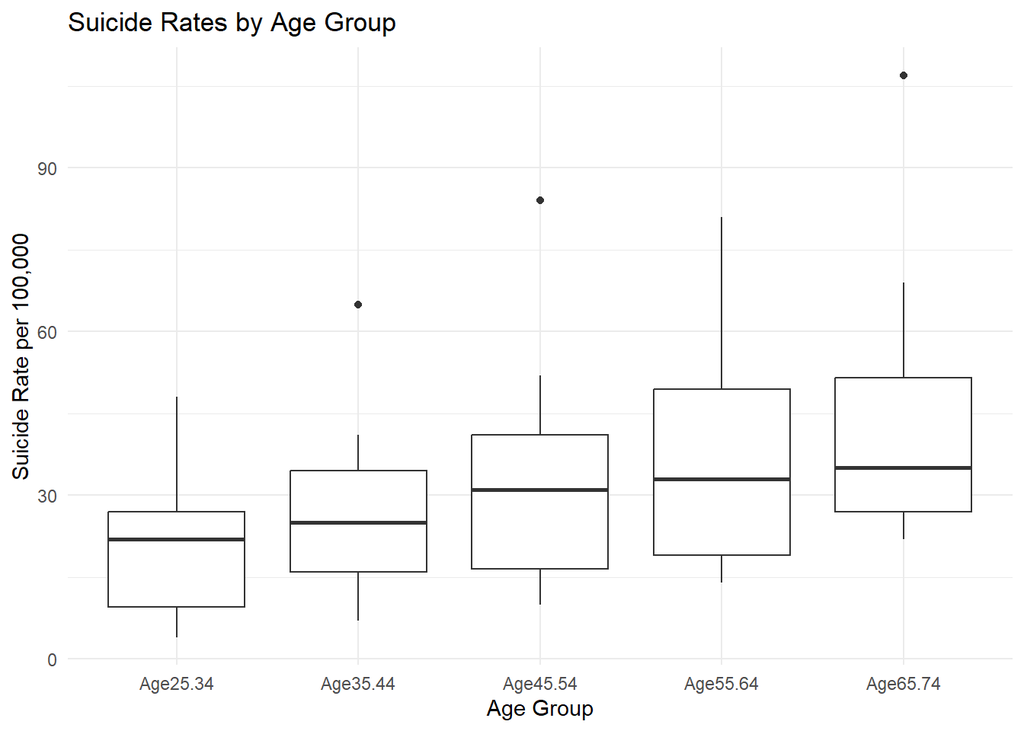

```r
 library(ggplot2)

# Constructing side-by-side box plots
ggplot(suicrates_long, aes(x = AgeGroup, y = Rate)) +
  geom_boxplot() +
  labs(title = "Suicide Rates by Age Group",
       x = "Age Group",
       y = "Suicide Rate per 100,000") +
  theme_minimal()
```

## 7.

```r
 data(pressure)
head(pressure)
```

```
##   temperature pressure
## 1           0   0.0002
## 2          20   0.0012
## 3          40   0.0060
## 4          60   0.0300
## 5          80   0.0900
## 6         100   0.2700
```

#### (2) Transform the data

According to the Clausius-Clapeyron equation, the logarithm of the vapor pressure is approximately inversely proportional to the absolute temperature (temperature + 273). We’ll transform the temperature to its absolute value and compute the logarithm of the vapor pressure:

```r
pressure$TemperatureK <- pressure$temperature + 273
pressure$log_pressure <- log(pressure$pressure)
```

#### (3) Plot the transformed data

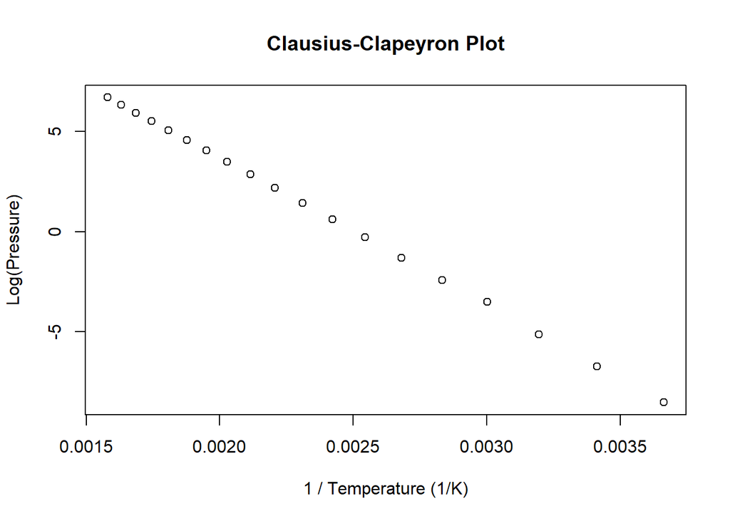

```r
plot(1 / pressure$TemperatureK, pressure$log_pressure,
     xlab = "1 / Temperature (1/K)",
     ylab = "Log(Pressure)",
     main = "Clausius-Clapeyron Plot")
```

#### (4) Fit a regression line

Fit a linear model to the transformed data:

```r
fit <- lm(log_pressure ~ I(1 / TemperatureK), data = pressure)
summary(fit)
```

```
##
## Call:
## lm(formula = log_pressure ~ I(1/TemperatureK), data = pressure)
##
## Residuals:
##       Min        1Q    Median        3Q       Max
## -0.074183 -0.028889 -0.002508  0.021144  0.151494
##
## Coefficients:
##                     Estimate Std. Error t value Pr(>|t|)
## (Intercept)        1.827e+01  4.429e-02   412.4   <2e-16 ***
## I(1/TemperatureK) -7.301e+03  1.822e+01  -400.7   <2e-16 ***
## ---
## Signif. codes:  0 '***' 0.001 '**' 0.01 '*' 0.05 '.' 0.1 ' ' 1
##
## Residual standard error: 0.04874 on 17 degrees of freedom
## Multiple R-squared:  0.9999, Adjusted R-squared:  0.9999
## F-statistic: 1.606e+05 on 1 and 17 DF,  p-value: < 2.2e-16
```

#### (5) Add the regression line to the plot

#### Here’s the complete R code for the entire process:

```r
# Load the pressure data set
data(pressure)
head(pressure)
```

```
##   temperature pressure
## 1           0   0.0002
## 2          20   0.0012
## 3          40   0.0060
## 4          60   0.0300
## 5          80   0.0900
## 6         100   0.2700
```

```r
# Transform the data
pressure$TemperatureK <- pressure$temperature + 273
pressure$log_pressure <- log(pressure$pressure)

# Plot the transformed data
plot(1 / pressure$TemperatureK, pressure$log_pressure,
     xlab = "1 / Temperature (1/K)",
     ylab = "Log(Pressure)",
     main = "Clausius-Clapeyron Plot")

# Fit a regression line
fit <- lm(log_pressure ~ I(1 / TemperatureK), data = pressure)
summary(fit)
```

```
##
## Call:
## lm(formula = log_pressure ~ I(1/TemperatureK), data = pressure)
##
## Residuals:
##       Min        1Q    Median        3Q       Max
## -0.074183 -0.028889 -0.002508  0.021144  0.151494
##
## Coefficients:
##                     Estimate Std. Error t value Pr(>|t|)
## (Intercept)        1.827e+01  4.429e-02   412.4   <2e-16 ***
## I(1/TemperatureK) -7.301e+03  1.822e+01  -400.7   <2e-16 ***
## ---
## Signif. codes:  0 '***' 0.001 '**' 0.01 '*' 0.05 '.' 0.1 ' ' 1
##
## Residual standard error: 0.04874 on 17 degrees of freedom
## Multiple R-squared:  0.9999, Adjusted R-squared:  0.9999
## F-statistic: 1.606e+05 on 1 and 17 DF,  p-value: < 2.2e-16
```

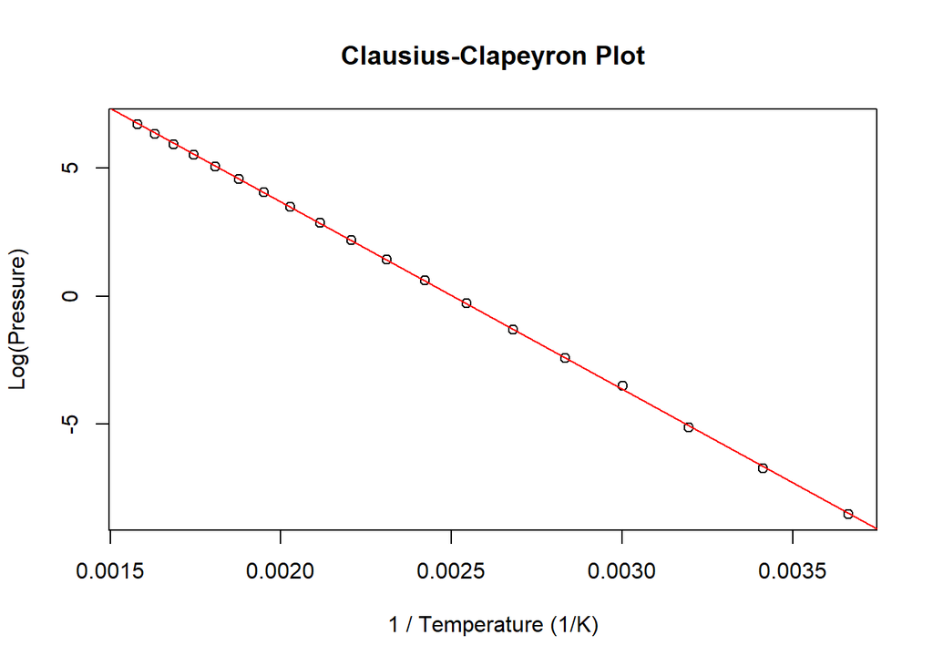

```r
# Add the regression line to the plot
abline(fit, col = "red")
```